# Risk Factor Analysis

## Outcome Variable

**Outcome Variable:** whz

## Predictor Variables

**Intervention Variable:** impfloor

**Adjustment Set:**

- arm
- sex
- W_mage
- meducyrs
- feducyrs
- hhwealth_quart
- hfoodsec
- W_mhtcm
- W_mwtkg
- W_mbmi
- W_nrooms
- W_nchldlt5
- W_parity
- impsan
- safeh20
- delta_W_mage
- delta_meducyrs
- delta_feducyrs
- delta_hhwealth_quart
- delta_hfoodsec
- delta_W_mhtcm
- delta_W_mwtkg
- delta_W_mbmi
- delta_W_nrooms
- delta_W_nchldlt5
- delta_W_parity
- delta_impsan
- delta_safeh20

## Stratifying Variables

The analysis was stratified on these variable(s):

- agecat
- studyid
- country

## Data Summary

| agecat | studyid | country | impfloor | n_cell | n | outcome_variable |
| --- | --- | --- | --- | --- | --- | --- |
| Birth | CMC-V-BCS-2002 | INDIA | 1 | 68 | 68 | whz |
| Birth | CMC-V-BCS-2002 | INDIA | 0 | 0 | 68 | whz |
| Birth | CONTENT | PERU | 1 | 2 | 2 | whz |
| Birth | CONTENT | PERU | 0 | 0 | 2 | whz |
| Birth | GMS-Nepal | NEPAL | 1 | 97 | 503 | whz |
| Birth | GMS-Nepal | NEPAL | 0 | 406 | 503 | whz |
| Birth | IRC | INDIA | 1 | 253 | 253 | whz |
| Birth | IRC | INDIA | 0 | 0 | 253 | whz |
| Birth | JiVitA-3 | BANGLADESH | 1 | 1215 | 17966 | whz |
| Birth | JiVitA-3 | BANGLADESH | 0 | 16751 | 17966 | whz |
| Birth | JiVitA-4 | BANGLADESH | 1 | 271 | 2394 | whz |
| Birth | JiVitA-4 | BANGLADESH | 0 | 2123 | 2394 | whz |
| Birth | MAL-ED | BANGLADESH | 1 | 185 | 201 | whz |
| Birth | MAL-ED | BANGLADESH | 0 | 16 | 201 | whz |
| Birth | MAL-ED | BRAZIL | 1 | 55 | 57 | whz |
| Birth | MAL-ED | BRAZIL | 0 | 2 | 57 | whz |
| Birth | MAL-ED | INDIA | 1 | 33 | 39 | whz |
| Birth | MAL-ED | INDIA | 0 | 6 | 39 | whz |
| Birth | MAL-ED | NEPAL | 1 | 8 | 24 | whz |
| Birth | MAL-ED | NEPAL | 0 | 16 | 24 | whz |
| Birth | MAL-ED | PERU | 1 | 37 | 210 | whz |
| Birth | MAL-ED | PERU | 0 | 173 | 210 | whz |
| Birth | MAL-ED | SOUTH AFRICA | 1 | 86 | 95 | whz |
| Birth | MAL-ED | SOUTH AFRICA | 0 | 9 | 95 | whz |
| Birth | MAL-ED | TANZANIA, UNITED REPUBLIC OF | 1 | 5 | 111 | whz |
| Birth | MAL-ED | TANZANIA, UNITED REPUBLIC OF | 0 | 106 | 111 | whz |
| Birth | NIH-Birth | BANGLADESH | 1 | 505 | 572 | whz |
| Birth | NIH-Birth | BANGLADESH | 0 | 67 | 572 | whz |
| Birth | NIH-Crypto | BANGLADESH | 1 | 542 | 707 | whz |
| Birth | NIH-Crypto | BANGLADESH | 0 | 165 | 707 | whz |

[output cut: 66 more lines]

The following strata were considered:

- agecat: 24 months, studyid: CMC-V-BCS-2002, country: INDIA
- agecat: 24 months, studyid: CONTENT, country: PERU
- agecat: 24 months, studyid: GMS-Nepal, country: NEPAL
- agecat: 24 months, studyid: IRC, country: INDIA
- agecat: 24 months, studyid: JiVitA-3, country: BANGLADESH
- agecat: 24 months, studyid: JiVitA-4, country: BANGLADESH
- agecat: 24 months, studyid: MAL-ED, country: BANGLADESH
- agecat: 24 months, studyid: MAL-ED, country: BRAZIL
- agecat: 24 months, studyid: MAL-ED, country: INDIA
- agecat: 24 months, studyid: MAL-ED, country: NEPAL
- agecat: 24 months, studyid: MAL-ED, country: PERU
- agecat: 24 months, studyid: MAL-ED, country: SOUTH AFRICA
- agecat: 24 months, studyid: MAL-ED, country: TANZANIA, UNITED REPUBLIC OF
- agecat: 24 months, studyid: NIH-Birth, country: BANGLADESH
- agecat: 24 months, studyid: NIH-Crypto, country: BANGLADESH
- agecat: 24 months, studyid: PROVIDE, country: BANGLADESH
- agecat: 6 months, studyid: CMC-V-BCS-2002, country: INDIA
- agecat: 6 months, studyid: CONTENT, country: PERU
- agecat: 6 months, studyid: GMS-Nepal, country: NEPAL
- agecat: 6 months, studyid: IRC, country: INDIA
- agecat: 6 months, studyid: JiVitA-3, country: BANGLADESH
- agecat: 6 months, studyid: JiVitA-4, country: BANGLADESH
- agecat: 6 months, studyid: MAL-ED, country: BANGLADESH
- agecat: 6 months, studyid: MAL-ED, country: BRAZIL
- agecat: 6 months, studyid: MAL-ED, country: INDIA
- agecat: 6 months, studyid: MAL-ED, country: NEPAL
- agecat: 6 months, studyid: MAL-ED, country: PERU
- agecat: 6 months, studyid: MAL-ED, country: SOUTH AFRICA
- agecat: 6 months, studyid: MAL-ED, country: TANZANIA, UNITED REPUBLIC OF
- agecat: 6 months, studyid: NIH-Birth, country: BANGLADESH
- agecat: 6 months, studyid: NIH-Crypto, country: BANGLADESH
- agecat: 6 months, studyid: PROVIDE, country: BANGLADESH
- agecat: Birth, studyid: CMC-V-BCS-2002, country: INDIA
- agecat: Birth, studyid: CONTENT, country: PERU
- agecat: Birth, studyid: GMS-Nepal, country: NEPAL
- agecat: Birth, studyid: IRC, country: INDIA
- agecat: Birth, studyid: JiVitA-3, country: BANGLADESH
- agecat: Birth, studyid: JiVitA-4, country: BANGLADESH
- agecat: Birth, studyid: MAL-ED, country: BANGLADESH
- agecat: Birth, studyid: MAL-ED, country: BRAZIL
- agecat: Birth, studyid: MAL-ED, country: INDIA
- agecat: Birth, studyid: MAL-ED, country: NEPAL
- agecat: Birth, studyid: MAL-ED, country: PERU
- agecat: Birth, studyid: MAL-ED, country: SOUTH AFRICA
- agecat: Birth, studyid: MAL-ED, country: TANZANIA, UNITED REPUBLIC OF
- agecat: Birth, studyid: NIH-Birth, country: BANGLADESH
- agecat: Birth, studyid: NIH-Crypto, country: BANGLADESH
- agecat: Birth, studyid: PROVIDE, country: BANGLADESH

### Dropped Strata

Some strata were dropped due to rare outcomes:

- agecat: Birth, studyid: CMC-V-BCS-2002, country: INDIA
- agecat: Birth, studyid: CONTENT, country: PERU
- agecat: Birth, studyid: IRC, country: INDIA
- agecat: Birth, studyid: MAL-ED, country: BRAZIL
- agecat: 6 months, studyid: CMC-V-BCS-2002, country: INDIA
- agecat: 6 months, studyid: IRC, country: INDIA
- agecat: 6 months, studyid: MAL-ED, country: BRAZIL
- agecat: 24 months, studyid: CMC-V-BCS-2002, country: INDIA
- agecat: 24 months, studyid: IRC, country: INDIA
- agecat: 24 months, studyid: MAL-ED, country: BRAZIL

## Methods Detail

We’re interested in the causal parameters $E[Y_a]$ for all values of $a \in \mathcal{A}$. These parameters represent the mean outcome if, possibly contrary to fact, we intervened to set all units to have $A=a$. Under the randomization and positivity assumptions, these are identified by the statistical parameters $\psi_a=E_W[E_{Y|A,W}(Y|A=a,W)]$. In addition, we’re interested in the mean of $Y$, $E[Y]$ under no intervention (the observed mean). We will estimate these parameters by using SuperLearner to fit the relevant likelihood factors – $E_{Y|A,W}(Y|A=a,W)$ and $p(A=a|W)$, and then updating our likelihood fit using a joint TMLE.

For unadjusted analyses ($W=\{\}$), initial likelihoods were estimated using Lrnr_glm to estimate the simple $E(Y|A)$ and Lrnr_mean to estimate $p(A)$. For adjusted analyses, a small library containing Lrnr_glmnet, Lrnr_xgboost, and Lrnr_mean was used.

Having estimated these parameters, we will then use the delta method to estimate relative risks and attributable risks relative to a prespecified baseline level of $A$.

# Results Detail

## Results Plots

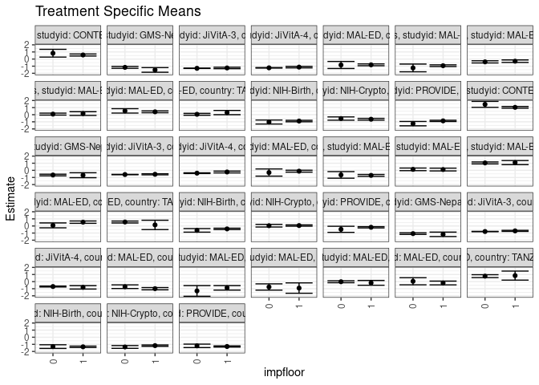

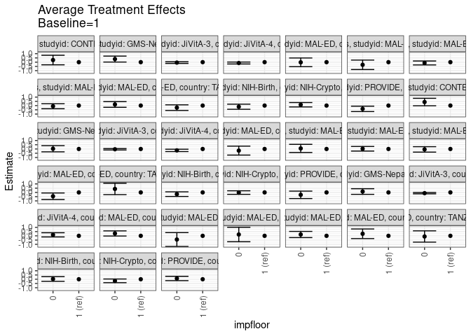

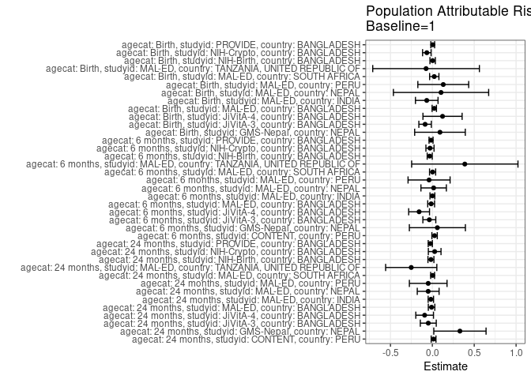

## Results Table

### Parameter: TSM

| agecat | studyid | country | intervention_level | baseline_level | estimate | ci_lower | ci_upper |
| --- | --- | --- | --- | --- | --- | --- | --- |
| Birth | GMS-Nepal | NEPAL | 1 | NA | -1.1772428 | -1.4892199 | -0.8652658 |
| Birth | GMS-Nepal | NEPAL | 0 | NA | -1.0745849 | -1.1884737 | -0.9606961 |
| Birth | JiVitA-3 | BANGLADESH | 1 | NA | -0.6908950 | -0.7665955 | -0.6151945 |
| Birth | JiVitA-3 | BANGLADESH | 0 | NA | -0.7790826 | -0.7992152 | -0.7589499 |
| Birth | JiVitA-4 | BANGLADESH | 1 | NA | -0.8099748 | -1.0496959 | -0.5702537 |
| Birth | JiVitA-4 | BANGLADESH | 0 | NA | -0.6926665 | -0.7589266 | -0.6264065 |
| Birth | MAL-ED | BANGLADESH | 1 | NA | -0.9959305 | -1.1555578 | -0.8363031 |
| Birth | MAL-ED | BANGLADESH | 0 | NA | -0.7167584 | -0.9730306 | -0.4604861 |
| Birth | MAL-ED | INDIA | 1 | NA | -0.8772727 | -1.1935310 | -0.5610144 |
| Birth | MAL-ED | INDIA | 0 | NA | -1.3116667 | -2.0623390 | -0.5609943 |
| Birth | MAL-ED | NEPAL | 1 | NA | -0.9125000 | -1.6413488 | -0.1836512 |
| Birth | MAL-ED | NEPAL | 0 | NA | -0.7568750 | -1.1980753 | -0.3156747 |
| Birth | MAL-ED | PERU | 1 | NA | -0.1772785 | -0.5153779 | 0.1608210 |
| Birth | MAL-ED | PERU | 0 | NA | -0.0190150 | -0.1545925 | 0.1165624 |
| Birth | MAL-ED | SOUTH AFRICA | 1 | NA | -0.1959302 | -0.4617510 | 0.0698905 |
| Birth | MAL-ED | SOUTH AFRICA | 0 | NA | 0.0466667 | -0.4532880 | 0.5466213 |
| Birth | MAL-ED | TANZANIA, UNITED REPUBLIC OF | 1 | NA | 0.8440000 | 0.2094403 | 1.4785597 |
| Birth | MAL-ED | TANZANIA, UNITED REPUBLIC OF | 0 | NA | 0.7655660 | 0.5608207 | 0.9703114 |
| Birth | NIH-Birth | BANGLADESH | 1 | NA | -1.3484268 | -1.4502362 | -1.2466174 |
| Birth | NIH-Birth | BANGLADESH | 0 | NA | -1.3179721 | -1.5745244 | -1.0614198 |
| Birth | NIH-Crypto | BANGLADESH | 1 | NA | -1.1784526 | -1.2730078 | -1.0838975 |
| Birth | NIH-Crypto | BANGLADESH | 0 | NA | -1.3672921 | -1.5629570 | -1.1716271 |
| Birth | PROVIDE | BANGLADESH | 1 | NA | -1.3030421 | -1.3836089 | -1.2224753 |
| Birth | PROVIDE | BANGLADESH | 0 | NA | -1.2125100 | -1.4556559 | -0.9693641 |
| 6 months | CONTENT | PERU | 1 | NA | 1.0378048 | 0.9162955 | 1.1593142 |
| 6 months | CONTENT | PERU | 0 | NA | 1.4542950 | 1.0353621 | 1.8732278 |
| 6 months | GMS-Nepal | NEPAL | 1 | NA | -0.6874890 | -1.0356006 | -0.3393774 |
| 6 months | GMS-Nepal | NEPAL | 0 | NA | -0.6572044 | -0.7706041 | -0.5438047 |
| 6 months | JiVitA-3 | BANGLADESH | 1 | NA | -0.5567253 | -0.6340193 | -0.4794313 |
| 6 months | JiVitA-3 | BANGLADESH | 0 | NA | -0.5890242 | -0.6123333 | -0.5657151 |
| 6 months | JiVitA-4 | BANGLADESH | 1 | NA | -0.2319639 | -0.3593730 | -0.1045548 |
| 6 months | JiVitA-4 | BANGLADESH | 0 | NA | -0.3969506 | -0.4465556 | -0.3473456 |
| 6 months | MAL-ED | BANGLADESH | 1 | NA | -0.1190365 | -0.2530380 | 0.0149649 |
| 6 months | MAL-ED | BANGLADESH | 0 | NA | -0.3096401 | -0.8168967 | 0.1976165 |
| 6 months | MAL-ED | INDIA | 1 | NA | -0.7109149 | -0.8445881 | -0.5772417 |
| 6 months | MAL-ED | INDIA | 0 | NA | -0.6441761 | -1.1063222 | -0.1820299 |
| 6 months | MAL-ED | NEPAL | 1 | NA | 0.1125504 | -0.0844384 | 0.3095393 |
| 6 months | MAL-ED | NEPAL | 0 | NA | 0.1386048 | -0.0462214 | 0.3234311 |
| 6 months | MAL-ED | PERU | 1 | NA | 1.0902480 | 0.8020744 | 1.3784217 |
| 6 months | MAL-ED | PERU | 0 | NA | 1.0421067 | 0.9065233 | 1.1776901 |
| 6 months | MAL-ED | SOUTH AFRICA | 1 | NA | 0.5373774 | 0.3738950 | 0.7008599 |
| 6 months | MAL-ED | SOUTH AFRICA | 0 | NA | 0.0846448 | -0.2582799 | 0.4275696 |
| 6 months | MAL-ED | TANZANIA, UNITED REPUBLIC OF | 1 | NA | 0.1478846 | -0.5083517 | 0.8041210 |
| 6 months | MAL-ED | TANZANIA, UNITED REPUBLIC OF | 0 | NA | 0.5561607 | 0.4210770 | 0.6912443 |
| 6 months | NIH-Birth | BANGLADESH | 1 | NA | -0.4134026 | -0.5098138 | -0.3169915 |
| 6 months | NIH-Birth | BANGLADESH | 0 | NA | -0.6179151 | -0.8718766 | -0.3639535 |
| 6 months | NIH-Crypto | BANGLADESH | 1 | NA | 0.0579310 | -0.0339734 | 0.1498354 |
| 6 months | NIH-Crypto | BANGLADESH | 0 | NA | 0.0389675 | -0.1498523 | 0.2277873 |
| 6 months | PROVIDE | BANGLADESH | 1 | NA | -0.1835831 | -0.2705821 | -0.0965841 |
| 6 months | PROVIDE | BANGLADESH | 0 | NA | -0.4696558 | -0.8981106 | -0.0412009 |
| 24 months | CONTENT | PERU | 1 | NA | 0.5757317 | 0.4353553 | 0.7161082 |
| 24 months | CONTENT | PERU | 0 | NA | 0.8253537 | 0.2793535 | 1.3713539 |
| 24 months | GMS-Nepal | NEPAL | 1 | NA | -1.5284202 | -1.8529108 | -1.2039295 |
| 24 months | GMS-Nepal | NEPAL | 0 | NA | -1.1649268 | -1.2983491 | -1.0315045 |
| 24 months | JiVitA-3 | BANGLADESH | 1 | NA | -1.2484854 | -1.3477608 | -1.1492101 |
| 24 months | JiVitA-3 | BANGLADESH | 0 | NA | -1.2991572 | -1.3241358 | -1.2741786 |
| 24 months | JiVitA-4 | BANGLADESH | 1 | NA | -1.1313671 | -1.2382015 | -1.0245327 |
| 24 months | JiVitA-4 | BANGLADESH | 0 | NA | -1.2326043 | -1.2724814 | -1.1927271 |
| 24 months | MAL-ED | BANGLADESH | 1 | NA | -0.8101045 | -0.9363650 | -0.6838440 |
| 24 months | MAL-ED | BANGLADESH | 0 | NA | -0.8316448 | -1.3259034 | -0.3373863 |
| 24 months | MAL-ED | INDIA | 1 | NA | -0.9338250 | -1.0542610 | -0.8133890 |
| 24 months | MAL-ED | INDIA | 0 | NA | -1.2465828 | -1.7907136 | -0.7024521 |
| 24 months | MAL-ED | NEPAL | 1 | NA | -0.2973921 | -0.4717218 | -0.1230624 |
| 24 months | MAL-ED | NEPAL | 0 | NA | -0.3929189 | -0.5466774 | -0.2391605 |
| 24 months | MAL-ED | PERU | 1 | NA | 0.1606353 | -0.0995290 | 0.4207995 |
| 24 months | MAL-ED | PERU | 0 | NA | 0.0837727 | -0.0570718 | 0.2246172 |
| 24 months | MAL-ED | SOUTH AFRICA | 1 | NA | 0.4056882 | 0.2765012 | 0.5348753 |
| 24 months | MAL-ED | SOUTH AFRICA | 0 | NA | 0.5387673 | 0.2298081 | 0.8477266 |
| 24 months | MAL-ED | TANZANIA, UNITED REPUBLIC OF | 1 | NA | 0.2998291 | 0.0016143 | 0.5980440 |
| 24 months | MAL-ED | TANZANIA, UNITED REPUBLIC OF | 0 | NA | 0.0562533 | -0.0751600 | 0.1876666 |
| 24 months | NIH-Birth | BANGLADESH | 1 | NA | -0.8937943 | -0.9986760 | -0.7889125 |
| 24 months | NIH-Birth | BANGLADESH | 0 | NA | -1.0295447 | -1.3105903 | -0.7484991 |
| 24 months | NIH-Crypto | BANGLADESH | 1 | NA | -0.6382547 | -0.7604897 | -0.5160198 |
| 24 months | NIH-Crypto | BANGLADESH | 0 | NA | -0.5417008 | -0.7707685 | -0.3126332 |
| 24 months | PROVIDE | BANGLADESH | 1 | NA | -0.8682998 | -0.9541843 | -0.7824153 |
| 24 months | PROVIDE | BANGLADESH | 0 | NA | -1.2568181 | -1.5636857 | -0.9499506 |

### Parameter: E(Y)

| agecat | studyid | country | intervention_level | baseline_level | estimate | ci_lower | ci_upper |
| --- | --- | --- | --- | --- | --- | --- | --- |
| Birth | GMS-Nepal | NEPAL | NA | NA | -1.0860636 | -1.1830454 | -0.9890818 |
| Birth | JiVitA-3 | BANGLADESH | NA | NA | -0.7773511 | -0.7963777 | -0.7583245 |
| Birth | JiVitA-4 | BANGLADESH | NA | NA | -0.6882498 | -0.7406539 | -0.6358456 |
| Birth | MAL-ED | BANGLADESH | NA | NA | -0.9728358 | -1.1217009 | -0.8239707 |
| Birth | MAL-ED | INDIA | NA | NA | -0.9441026 | -1.2397919 | -0.6484132 |
| Birth | MAL-ED | NEPAL | NA | NA | -0.8087500 | -1.1914221 | -0.4260779 |
| Birth | MAL-ED | PERU | NA | NA | -0.0468095 | -0.1738806 | 0.0802616 |
| Birth | MAL-ED | SOUTH AFRICA | NA | NA | -0.1729474 | -0.4186222 | 0.0727275 |
| Birth | MAL-ED | TANZANIA, UNITED REPUBLIC OF | NA | NA | 0.7690991 | 0.5714748 | 0.9667234 |
| Birth | NIH-Birth | BANGLADESH | NA | NA | -1.3448514 | -1.4396716 | -1.2500312 |
| Birth | NIH-Crypto | BANGLADESH | NA | NA | -1.2441513 | -1.3281130 | -1.1601897 |
| Birth | PROVIDE | BANGLADESH | NA | NA | -1.2984586 | -1.3752758 | -1.2216415 |
| 6 months | CONTENT | PERU | NA | NA | 1.0644279 | 0.9468682 | 1.1819876 |
| 6 months | GMS-Nepal | NEPAL | NA | NA | -0.6273772 | -0.7253868 | -0.5293676 |
| 6 months | JiVitA-3 | BANGLADESH | NA | NA | -0.5926720 | -0.6122891 | -0.5730549 |
| 6 months | JiVitA-4 | BANGLADESH | NA | NA | -0.3901347 | -0.4273932 | -0.3528762 |
| 6 months | MAL-ED | BANGLADESH | NA | NA | -0.1333333 | -0.2623761 | -0.0042906 |
| 6 months | MAL-ED | INDIA | NA | NA | -0.7102872 | -0.8371659 | -0.5834085 |
| 6 months | MAL-ED | NEPAL | NA | NA | 0.1281441 | -0.0056126 | 0.2619008 |
| 6 months | MAL-ED | PERU | NA | NA | 1.0512099 | 0.9285617 | 1.1738581 |
| 6 months | MAL-ED | SOUTH AFRICA | NA | NA | 0.5404351 | 0.3867005 | 0.6941696 |
| 6 months | MAL-ED | TANZANIA, UNITED REPUBLIC OF | NA | NA | 0.5355782 | 0.4032519 | 0.6679046 |
| 6 months | NIH-Birth | BANGLADESH | NA | NA | -0.4447399 | -0.5354039 | -0.3540758 |
| 6 months | NIH-Crypto | BANGLADESH | NA | NA | 0.0297622 | -0.0491685 | 0.1086930 |
| 6 months | PROVIDE | BANGLADESH | NA | NA | -0.1990907 | -0.2817968 | -0.1163845 |
| 24 months | CONTENT | PERU | NA | NA | 0.5902439 | 0.4560143 | 0.7244735 |
| 24 months | GMS-Nepal | NEPAL | NA | NA | -1.1990840 | -1.3039914 | -1.0941766 |
| 24 months | JiVitA-3 | BANGLADESH | NA | NA | -1.2970420 | -1.3203145 | -1.2737694 |
| 24 months | JiVitA-4 | BANGLADESH | NA | NA | -1.2232311 | -1.2550891 | -1.1913732 |
| 24 months | MAL-ED | BANGLADESH | NA | NA | -0.8192925 | -0.9412667 | -0.6973182 |
| 24 months | MAL-ED | INDIA | NA | NA | -0.9516520 | -1.0670654 | -0.8362385 |
| 24 months | MAL-ED | NEPAL | NA | NA | -0.3471493 | -0.4618867 | -0.2324120 |
| 24 months | MAL-ED | PERU | NA | NA | 0.1111982 | -0.0118399 | 0.2342362 |
| 24 months | MAL-ED | SOUTH AFRICA | NA | NA | 0.4090301 | 0.2879441 | 0.5301161 |
| 24 months | MAL-ED | TANZANIA, UNITED REPUBLIC OF | NA | NA | 0.0477437 | -0.0779935 | 0.1734809 |
| 24 months | NIH-Birth | BANGLADESH | NA | NA | -0.9106710 | -1.0090143 | -0.8123277 |
| 24 months | NIH-Crypto | BANGLADESH | NA | NA | -0.6103502 | -0.7050157 | -0.5156847 |
| 24 months | PROVIDE | BANGLADESH | NA | NA | -0.8928670 | -0.9755153 | -0.8102187 |

### Parameter: ATE

| agecat | studyid | country | intervention_level | baseline_level | estimate | ci_lower | ci_upper |
| --- | --- | --- | --- | --- | --- | --- | --- |
| Birth | GMS-Nepal | NEPAL | 1 | 1 | 0.0000000 | 0.0000000 | 0.0000000 |
| Birth | GMS-Nepal | NEPAL | 0 | 1 | 0.1026579 | -0.2285863 | 0.4339022 |
| Birth | JiVitA-3 | BANGLADESH | 1 | 1 | 0.0000000 | 0.0000000 | 0.0000000 |
| Birth | JiVitA-3 | BANGLADESH | 0 | 1 | -0.0881876 | -0.1665418 | -0.0098333 |
| Birth | JiVitA-4 | BANGLADESH | 1 | 1 | 0.0000000 | 0.0000000 | 0.0000000 |
| Birth | JiVitA-4 | BANGLADESH | 0 | 1 | 0.1173083 | -0.1303127 | 0.3649292 |
| Birth | MAL-ED | BANGLADESH | 1 | 1 | 0.0000000 | 0.0000000 | 0.0000000 |
| Birth | MAL-ED | BANGLADESH | 0 | 1 | 0.2791721 | -0.0231705 | 0.5815147 |
| Birth | MAL-ED | INDIA | 1 | 1 | 0.0000000 | 0.0000000 | 0.0000000 |
| Birth | MAL-ED | INDIA | 0 | 1 | -0.4343939 | -1.2489664 | 0.3801785 |
| Birth | MAL-ED | NEPAL | 1 | 1 | 0.0000000 | 0.0000000 | 0.0000000 |
| Birth | MAL-ED | NEPAL | 0 | 1 | 0.1556250 | -0.6963599 | 1.0076099 |
| Birth | MAL-ED | PERU | 1 | 1 | 0.0000000 | 0.0000000 | 0.0000000 |
| Birth | MAL-ED | PERU | 0 | 1 | 0.1582634 | -0.2067797 | 0.5233066 |
| Birth | MAL-ED | SOUTH AFRICA | 1 | 1 | 0.0000000 | 0.0000000 | 0.0000000 |
| Birth | MAL-ED | SOUTH AFRICA | 0 | 1 | 0.2425969 | -0.3236321 | 0.8088259 |
| Birth | MAL-ED | TANZANIA, UNITED REPUBLIC OF | 1 | 1 | 0.0000000 | 0.0000000 | 0.0000000 |
| Birth | MAL-ED | TANZANIA, UNITED REPUBLIC OF | 0 | 1 | -0.0784340 | -0.7452073 | 0.5883394 |
| Birth | NIH-Birth | BANGLADESH | 1 | 1 | 0.0000000 | 0.0000000 | 0.0000000 |
| Birth | NIH-Birth | BANGLADESH | 0 | 1 | 0.0304547 | -0.2457660 | 0.3066754 |
| Birth | NIH-Crypto | BANGLADESH | 1 | 1 | 0.0000000 | 0.0000000 | 0.0000000 |
| Birth | NIH-Crypto | BANGLADESH | 0 | 1 | -0.1888395 | -0.4064738 | 0.0287949 |
| Birth | PROVIDE | BANGLADESH | 1 | 1 | 0.0000000 | 0.0000000 | 0.0000000 |
| Birth | PROVIDE | BANGLADESH | 0 | 1 | 0.0905322 | -0.1645862 | 0.3456505 |
| 6 months | CONTENT | PERU | 1 | 1 | 0.0000000 | 0.0000000 | 0.0000000 |
| 6 months | CONTENT | PERU | 0 | 1 | 0.4164901 | -0.0217038 | 0.8546840 |
| 6 months | GMS-Nepal | NEPAL | 1 | 1 | 0.0000000 | 0.0000000 | 0.0000000 |
| 6 months | GMS-Nepal | NEPAL | 0 | 1 | 0.0302846 | -0.3364844 | 0.3970536 |
| 6 months | JiVitA-3 | BANGLADESH | 1 | 1 | 0.0000000 | 0.0000000 | 0.0000000 |
| 6 months | JiVitA-3 | BANGLADESH | 0 | 1 | -0.0322989 | -0.1135086 | 0.0489108 |
| 6 months | JiVitA-4 | BANGLADESH | 1 | 1 | 0.0000000 | 0.0000000 | 0.0000000 |
| 6 months | JiVitA-4 | BANGLADESH | 0 | 1 | -0.1649867 | -0.3014357 | -0.0285376 |
| 6 months | MAL-ED | BANGLADESH | 1 | 1 | 0.0000000 | 0.0000000 | 0.0000000 |
| 6 months | MAL-ED | BANGLADESH | 0 | 1 | -0.1906036 | -0.7171524 | 0.3359453 |
| 6 months | MAL-ED | INDIA | 1 | 1 | 0.0000000 | 0.0000000 | 0.0000000 |
| 6 months | MAL-ED | INDIA | 0 | 1 | 0.0667389 | -0.4142381 | 0.5477158 |
| 6 months | MAL-ED | NEPAL | 1 | 1 | 0.0000000 | 0.0000000 | 0.0000000 |
| 6 months | MAL-ED | NEPAL | 0 | 1 | 0.0260544 | -0.2446727 | 0.2967815 |
| 6 months | MAL-ED | PERU | 1 | 1 | 0.0000000 | 0.0000000 | 0.0000000 |
| 6 months | MAL-ED | PERU | 0 | 1 | -0.0481414 | -0.3669048 | 0.2706221 |
| 6 months | MAL-ED | SOUTH AFRICA | 1 | 1 | 0.0000000 | 0.0000000 | 0.0000000 |
| 6 months | MAL-ED | SOUTH AFRICA | 0 | 1 | -0.4527326 | -0.8362388 | -0.0692263 |
| 6 months | MAL-ED | TANZANIA, UNITED REPUBLIC OF | 1 | 1 | 0.0000000 | 0.0000000 | 0.0000000 |
| 6 months | MAL-ED | TANZANIA, UNITED REPUBLIC OF | 0 | 1 | 0.4082760 | -0.2615788 | 1.0781309 |
| 6 months | NIH-Birth | BANGLADESH | 1 | 1 | 0.0000000 | 0.0000000 | 0.0000000 |
| 6 months | NIH-Birth | BANGLADESH | 0 | 1 | -0.2045124 | -0.4760747 | 0.0670499 |
| 6 months | NIH-Crypto | BANGLADESH | 1 | 1 | 0.0000000 | 0.0000000 | 0.0000000 |
| 6 months | NIH-Crypto | BANGLADESH | 0 | 1 | -0.0189635 | -0.2286587 | 0.1907316 |
| 6 months | PROVIDE | BANGLADESH | 1 | 1 | 0.0000000 | 0.0000000 | 0.0000000 |
| 6 months | PROVIDE | BANGLADESH | 0 | 1 | -0.2860727 | -0.7240027 | 0.1518574 |
| 24 months | CONTENT | PERU | 1 | 1 | 0.0000000 | 0.0000000 | 0.0000000 |
| 24 months | CONTENT | PERU | 0 | 1 | 0.2496219 | -0.3143698 | 0.8136136 |
| 24 months | GMS-Nepal | NEPAL | 1 | 1 | 0.0000000 | 0.0000000 | 0.0000000 |
| 24 months | GMS-Nepal | NEPAL | 0 | 1 | 0.3634934 | 0.0128003 | 0.7141864 |
| 24 months | JiVitA-3 | BANGLADESH | 1 | 1 | 0.0000000 | 0.0000000 | 0.0000000 |
| 24 months | JiVitA-3 | BANGLADESH | 0 | 1 | -0.0506718 | -0.1497853 | 0.0484418 |
| 24 months | JiVitA-4 | BANGLADESH | 1 | 1 | 0.0000000 | 0.0000000 | 0.0000000 |
| 24 months | JiVitA-4 | BANGLADESH | 0 | 1 | -0.1012371 | -0.2145999 | 0.0121256 |
| 24 months | MAL-ED | BANGLADESH | 1 | 1 | 0.0000000 | 0.0000000 | 0.0000000 |
| 24 months | MAL-ED | BANGLADESH | 0 | 1 | -0.0215403 | -0.5325356 | 0.4894551 |
| 24 months | MAL-ED | INDIA | 1 | 1 | 0.0000000 | 0.0000000 | 0.0000000 |
| 24 months | MAL-ED | INDIA | 0 | 1 | -0.3127578 | -0.8705895 | 0.2450739 |
| 24 months | MAL-ED | NEPAL | 1 | 1 | 0.0000000 | 0.0000000 | 0.0000000 |
| 24 months | MAL-ED | NEPAL | 0 | 1 | -0.0955268 | -0.3277351 | 0.1366814 |
| 24 months | MAL-ED | PERU | 1 | 1 | 0.0000000 | 0.0000000 | 0.0000000 |
| 24 months | MAL-ED | PERU | 0 | 1 | -0.0768626 | -0.3731904 | 0.2194652 |
| 24 months | MAL-ED | SOUTH AFRICA | 1 | 1 | 0.0000000 | 0.0000000 | 0.0000000 |
| 24 months | MAL-ED | SOUTH AFRICA | 0 | 1 | 0.1330791 | -0.2019373 | 0.4680955 |
| 24 months | MAL-ED | TANZANIA, UNITED REPUBLIC OF | 1 | 1 | 0.0000000 | 0.0000000 | 0.0000000 |
| 24 months | MAL-ED | TANZANIA, UNITED REPUBLIC OF | 0 | 1 | -0.2435758 | -0.5739125 | 0.0867608 |
| 24 months | NIH-Birth | BANGLADESH | 1 | 1 | 0.0000000 | 0.0000000 | 0.0000000 |
| 24 months | NIH-Birth | BANGLADESH | 0 | 1 | -0.1357504 | -0.4366205 | 0.1651197 |
| 24 months | NIH-Crypto | BANGLADESH | 1 | 1 | 0.0000000 | 0.0000000 | 0.0000000 |
| 24 months | NIH-Crypto | BANGLADESH | 0 | 1 | 0.0965539 | -0.1621087 | 0.3552165 |
| 24 months | PROVIDE | BANGLADESH | 1 | 1 | 0.0000000 | 0.0000000 | 0.0000000 |
| 24 months | PROVIDE | BANGLADESH | 0 | 1 | -0.3885183 | -0.7067357 | -0.0703010 |

### Parameter: PAR

| agecat | studyid | country | intervention_level | baseline_level | estimate | ci_lower | ci_upper |
| --- | --- | --- | --- | --- | --- | --- | --- |
| Birth | GMS-Nepal | NEPAL | 1 | NA | 0.0911792 | -0.2111204 | 0.3934788 |
| Birth | JiVitA-3 | BANGLADESH | 1 | NA | -0.0864561 | -0.1609880 | -0.0119241 |
| Birth | JiVitA-4 | BANGLADESH | 1 | NA | 0.1217250 | -0.1120781 | 0.3555281 |
| Birth | MAL-ED | BANGLADESH | 1 | NA | 0.0230946 | -0.0029498 | 0.0491391 |
| Birth | MAL-ED | INDIA | 1 | NA | -0.0668298 | -0.2016929 | 0.0680332 |
| Birth | MAL-ED | NEPAL | 1 | NA | 0.1037500 | -0.4650307 | 0.6725307 |
| Birth | MAL-ED | PERU | 1 | NA | 0.1304690 | -0.1731165 | 0.4340544 |
| Birth | MAL-ED | SOUTH AFRICA | 1 | NA | 0.0229829 | -0.0325492 | 0.0785150 |
| Birth | MAL-ED | TANZANIA, UNITED REPUBLIC OF | 1 | NA | -0.0749009 | -0.7116467 | 0.5618449 |
| Birth | NIH-Birth | BANGLADESH | 1 | NA | 0.0035754 | -0.0286374 | 0.0357882 |
| Birth | NIH-Crypto | BANGLADESH | 1 | NA | -0.0656987 | -0.1165183 | -0.0148792 |
| Birth | PROVIDE | BANGLADESH | 1 | NA | 0.0045835 | -0.0180882 | 0.0272551 |
| 6 months | CONTENT | PERU | 1 | NA | 0.0266231 | -0.0055673 | 0.0588134 |
| 6 months | GMS-Nepal | NEPAL | 1 | NA | 0.0601118 | -0.2744940 | 0.3947176 |
| 6 months | JiVitA-3 | BANGLADESH | 1 | NA | -0.0359467 | -0.1130831 | 0.0411898 |
| 6 months | JiVitA-4 | BANGLADESH | 1 | NA | -0.1581708 | -0.2825332 | -0.0338084 |
| 6 months | MAL-ED | BANGLADESH | 1 | NA | -0.0142968 | -0.0551445 | 0.0265509 |
| 6 months | MAL-ED | INDIA | 1 | NA | 0.0006277 | -0.0281624 | 0.0294177 |
| 6 months | MAL-ED | NEPAL | 1 | NA | 0.0155937 | -0.1362582 | 0.1674455 |
| 6 months | MAL-ED | PERU | 1 | NA | -0.0390382 | -0.2900395 | 0.2119631 |
| 6 months | MAL-ED | SOUTH AFRICA | 1 | NA | 0.0030576 | -0.0334552 | 0.0395705 |
| 6 months | MAL-ED | TANZANIA, UNITED REPUBLIC OF | 1 | NA | 0.3876936 | -0.2470460 | 1.0224332 |
| 6 months | NIH-Birth | BANGLADESH | 1 | NA | -0.0313372 | -0.0615486 | -0.0011259 |
| 6 months | NIH-Crypto | BANGLADESH | 1 | NA | -0.0281688 | -0.0767352 | 0.0203976 |
| 6 months | PROVIDE | BANGLADESH | 1 | NA | -0.0155075 | -0.0393726 | 0.0083575 |
| 24 months | CONTENT | PERU | 1 | NA | 0.0145122 | -0.0140082 | 0.0430325 |
| 24 months | GMS-Nepal | NEPAL | 1 | NA | 0.3293362 | 0.0172407 | 0.6414316 |
| 24 months | JiVitA-3 | BANGLADESH | 1 | NA | -0.0485565 | -0.1437699 | 0.0466568 |
| 24 months | JiVitA-4 | BANGLADESH | 1 | NA | -0.0918640 | -0.1974777 | 0.0137497 |
| 24 months | MAL-ED | BANGLADESH | 1 | NA | -0.0091879 | -0.0480153 | 0.0296394 |
| 24 months | MAL-ED | INDIA | 1 | NA | -0.0178270 | -0.0500425 | 0.0143886 |
| 24 months | MAL-ED | NEPAL | 1 | NA | -0.0497572 | -0.1800014 | 0.0804870 |
| 24 months | MAL-ED | PERU | 1 | NA | -0.0494371 | -0.2742726 | 0.1753985 |
| 24 months | MAL-ED | SOUTH AFRICA | 1 | NA | 0.0033419 | -0.0199851 | 0.0266689 |
| 24 months | MAL-ED | TANZANIA, UNITED REPUBLIC OF | 1 | NA | -0.2520854 | -0.5577186 | 0.0535478 |
| 24 months | NIH-Birth | BANGLADESH | 1 | NA | -0.0168767 | -0.0524701 | 0.0187167 |
| 24 months | NIH-Crypto | BANGLADESH | 1 | NA | 0.0279046 | -0.0477533 | 0.1035624 |
| 24 months | PROVIDE | BANGLADESH | 1 | NA | -0.0245672 | -0.0492545 | 0.0001201 |